# Progress Memo 1

Final Project  
Data Science 2 with R (STAT 301-2)

Author

Mackenzie Lanning

**Github Repo Link**

[Lanning_Mackenzie_Progress_Memo_1](https://github.com/stat301-2-2025-winter/final-project-2-MLanning314)

## Prediction Problem

My prediction objective is to predict the Air Quality Index value across various cities in India. With an increase in climate change and pollution levels, this prediction problem is crucial for public health, environmental protection, and policy-making. India faces severe air pollution challenges, particularly in urban areas, which have some of the highest pollution levels globally. Accurate predictions of AQI allow for early warnings and enable residents to take preventive measures, such as limiting outdoor activities or using air purifiers, thereby reducing exposure to harmful pollutants like particulate matter (PM2.5 and PM10), nitrogen oxides, and sulfur dioxide. Additionally, reliable AQI predictions help inform governmental and regulatory decisions, such as issuing advisories, formulating air quality standards, and implementing targeted interventions to improve air quality. By understanding and forecasting AQI trends, India can better address the long-term health impacts of air pollution, reduce healthcare costs, and create more sustainable cities for its growing population.

This is a regression prediction problem, as the outcome variable I want to predict is continuous on a numeric scale. I am personally interested in this project as I am an environmental science major with a particular interest in environmental chemistry, specifically pertaining to air pollutants. I hope that analyzing this dataset will give me practical R knowledge in a field I would like to enter into after graduation.

## Data Source

My dataset is an Air Quality Index Dataset[^1] from Kaggle, created by Vopani. It includes very in-depth data on the Air Quality Index (AQI) of various cities throughout India, including data about the levels of specific pollutants. The data has 16 variables with 29,500 observations - these variables include 2 character variables, one date/time variable, and 13 numeric variables.

<sup>1</sup> [Air Quality Data in India (2015 - 2020) — https://www.kaggle.com/datasets/rohanrao/air-quality-data-in-india?select=city_day.csv)](https://www.kaggle.com/datasets/rohanrao/air-quality-data-in-india?select=city_day.csv)

## Data Quality Check

```
[1] 29531    16
```

Data summary

| Name | air_data |
| --- | --- |
| Number of rows | 29531 |
| Number of columns | 16 |
| _______________________ |  |
| Column type frequency: |  |
| character | 2 |
| Date | 1 |
| numeric | 13 |
| ________________________ |  |
| Group variables | None |

**Variable type: character**

| skim_variable | n_missing | complete_rate | min | max | empty | n_unique | whitespace |
| --- | --- | --- | --- | --- | --- | --- | --- |
| city | 0 | 1.00 | 5 | 18 | 0 | 26 | 0 |
| aqi_bucket | 4681 | 0.84 | 4 | 12 | 0 | 6 | 0 |

**Variable type: Date**

| skim_variable | n_missing | complete_rate | min | max | median | n_unique |
| --- | --- | --- | --- | --- | --- | --- |
| date | 0 | 1 | 2015-01-01 | 2020-07-01 | 2018-08-05 | 2009 |

**Variable type: numeric**

| skim_variable | n_missing | complete_rate | mean | sd | p0 | p25 | p50 | p75 | p100 |
| --- | --- | --- | --- | --- | --- | --- | --- | --- | --- |
| pm2_5 | 4598 | 0.84 | 67.45 | 64.66 | 0.04 | 28.82 | 48.57 | 80.59 | 949.99 |
| pm10 | 11140 | 0.62 | 118.13 | 90.61 | 0.01 | 56.25 | 95.68 | 149.74 | 1000.00 |
| no | 3582 | 0.88 | 17.57 | 22.79 | 0.02 | 5.63 | 9.89 | 19.95 | 390.68 |
| no2 | 3585 | 0.88 | 28.56 | 24.47 | 0.01 | 11.75 | 21.69 | 37.62 | 362.21 |
| n_ox | 4185 | 0.86 | 32.31 | 31.65 | 0.00 | 12.82 | 23.52 | 40.13 | 467.63 |
| nh3 | 10328 | 0.65 | 23.48 | 25.68 | 0.01 | 8.58 | 15.85 | 30.02 | 352.89 |
| co | 2059 | 0.93 | 2.25 | 6.96 | 0.00 | 0.51 | 0.89 | 1.45 | 175.81 |
| so2 | 3854 | 0.87 | 14.53 | 18.13 | 0.01 | 5.67 | 9.16 | 15.22 | 193.86 |
| o3 | 4022 | 0.86 | 34.49 | 21.69 | 0.01 | 18.86 | 30.84 | 45.57 | 257.73 |
| benzene | 5623 | 0.81 | 3.28 | 15.81 | 0.00 | 0.12 | 1.07 | 3.08 | 455.03 |
| toluene | 8041 | 0.73 | 8.70 | 19.97 | 0.00 | 0.60 | 2.97 | 9.15 | 454.85 |
| xylene | 18109 | 0.39 | 3.07 | 6.32 | 0.00 | 0.14 | 0.98 | 3.35 | 170.37 |
| aqi | 4681 | 0.84 | 166.46 | 140.70 | 13.00 | 81.00 | 118.00 | 208.00 | 2049.00 |

The `air_data` dataset has 29531 observations, and 16 variables. For this raw data, there are two categorical variables, with both being character variables: `city` and `aqi_bucket`. There is one date/time variable: `date`. There are 13 numeric variables that measure the concentration of pollutants in the air: `pm2_5`, `pm10`, `no`, `no2`, `n_ox`, `nh3`, `co`, `so2`, `o3`, `benzene`, `toulene`, and `xylene` - there is one numeric variable that is the direct measurement of the AQI - `aqi`. I will likely convert `aqi_bucket` to an ordered factor, as it seems it would function better as a factor than a character.

There are not an overwhelming amount of interesting/weird values, but the maximum values for the concentration of different pollutants is very large. This is not unreasonable, but just shocking as to how polluted different cities in India have been on any given day. There are also very low values for the minimum pollutant concentration, which goes to show that not all cities are struggling with the same pollution issues as others. Other than those observations, the values seem reasonable, and I feel comfortable proceeding with the data.

## Target Variable Analysis

I will now conduct a short analysis on my potential target variable: `aqi`

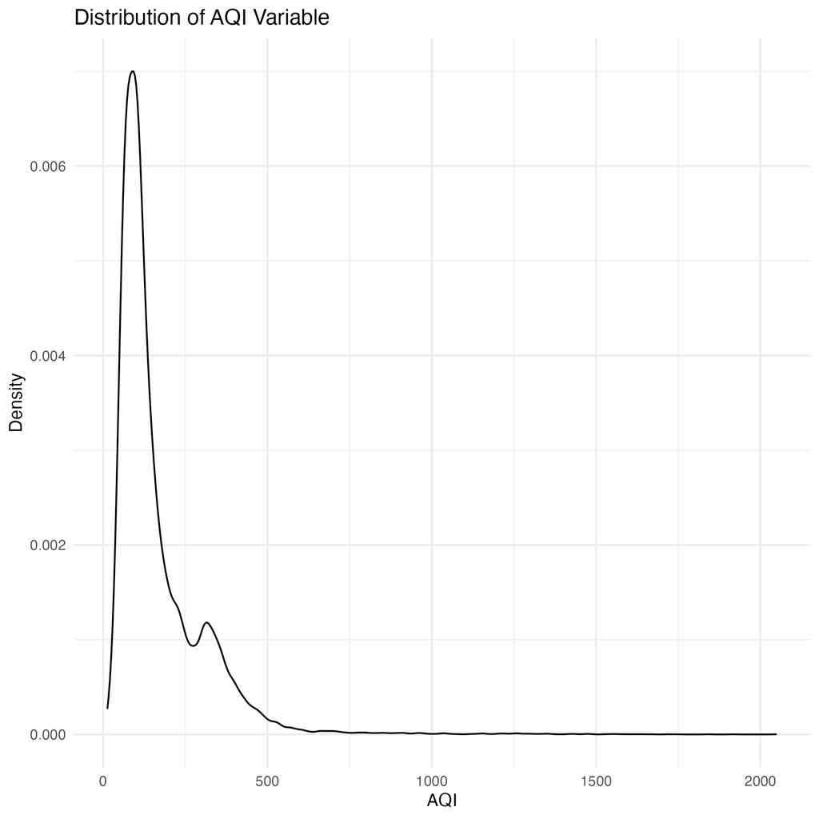

Figure 1: Distribution of the AQI Variable

As seen in Figure 1, my target variable has a significant right skew and will likely need a transformation. A skewed target variable can negatively impact a prediction model by causing bias and overprediction, so I will perform a log10 transformation on the target variable to see if that helps the distribution at all.

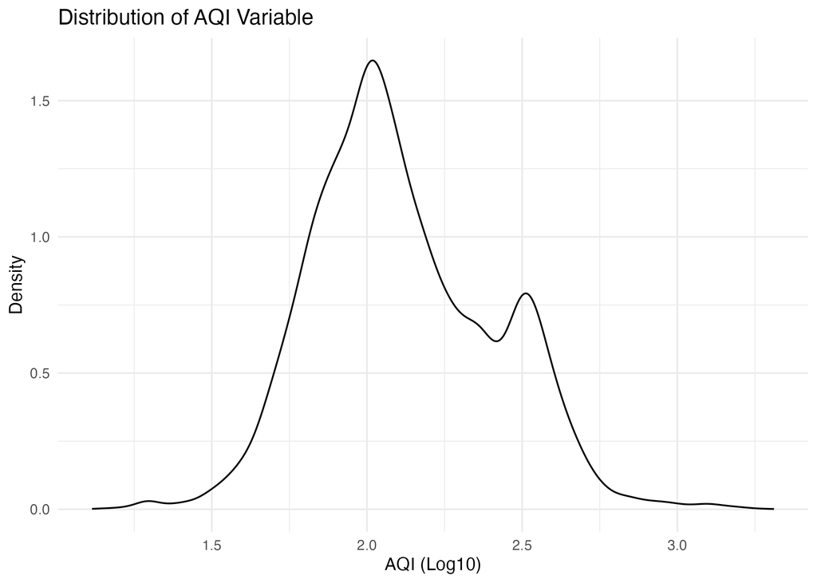

Figure 2: Distribution of the AQI Variable with a Log Distribution

The log10 transformation appears to improve the target variable distribution, as seen in Figure 2. There is a small degree of bimodality, but I do not think this will significantly impact the prediction model outcome. I plan on using this transformation when predicting my values, and then I can convert the values back to their original AQI value after they have been predicted by the model.

## Misc

I would love any criticism and feedback about this project! Pending approval, I will start with fitting the model and creating a recipe for this problem shortly.

## Citation

Air Quality Data in India (2015 - 2020). (2020). [Dataset]. Kaggle. https://www.kaggle.com/datasets/rohanrao/air-quality-data-in-india?select=city_day.csv